[Dewey research project](https://davidchivers.github.io/davidchivers.co.uk/dewey/)

# Dewey: public supply evidence and source record

20 October 2026 | Exposure, mixing and attitudes

Dark mode

20 October 2026. Complete authored result note, unchanged prospective protocol, construction log, independent review and response, plus the separate Green Book source qualification. No geographic source rows, private correspondence or restricted inputs are included. Machine-specific paths in the construction log are replaced by the explicit placeholders `PYTHON_EXECUTABLE`, `PANDOC_EXECUTABLE` and `PUBLIC_DATA_ROOT`.

The source note’s original local-delivery paragraph is preserved as a dated record. This website copy does not imply a shared Project upload. No original protocol, estimate or failed gate is superseded.

# Restaurant supply and city size: a public-data benchmark

20 October 2026. New empirical supporting analysis for rank 2, using public Census data only. Not the income-separation pilot, a causal mechanism test, or a claim of a new standalone contribution.

## The result in plain English

Larger metropolitan areas have more restaurants, but full-service restaurant numbers rise almost in proportion to the number of residents. Across 308 geographically comparable metros, doubling population is associated with about **2.03 times as many full-service establishments**, or **1.6% more per resident**. The model-based interval includes exact proportionality.

This does not refute the proposed choice mechanism. Twice as many venues can still allow more sorting, even if population also doubles. A large positive relationship between city population and venue counts is therefore not sufficient evidence for that mechanism. We must measure accessible alternatives and use of those alternatives, not mistake the mechanical size relationship for evidence of segregation.

## Data and model

The outcome is the published count of employer establishments in each of four fixed 2017 NAICS industries in the **2019 County Business Patterns** metropolitan file. The regressor is log metropolitan population, constructed from Vintage 2019 county population. There is one observation per metro, one cross-section, equal metro weights, and an intercept. There are no individual incomes, visits, worker profiles, attitude outcomes, year effects or other controls in these regressions.

For each industry separately:

$$\log(N_m)=\alpha+\beta\log(P_m)+\varepsilon_m.$$

Here $N_m$ is establishments and $P_m$ is residents. The reference value is **beta = 1**, which means proportionate supply, not beta = 0. Doubling population corresponds to a fitted count ratio of $2^\beta$, and to $100[2^{\beta-1}-1]$% more establishments per resident. These are cross-sectional associations, not effects of making a city bigger.

Sources: [2019 CBP files](https://www2.census.gov/programs-surveys/cbp/datasets/2019/), [CBP county-membership reference](https://www.census.gov/programs-surveys/cbp/technical-documentation/reference/metro-area-geography-reference.html), [2017 NAICS labels](https://www.census.gov/programs-surveys/cbp/technical-documentation/reference/naics-descriptions.html), and the previously verified population construction in note 99. The prospective protocol fixed the four industries and both geographic samples before establishment counts were downloaded or read.

## Complete primary results

Primary sample: US metropolitan areas with the **same complete county set and metropolitan status** in the CBP reference and September 2018 population reference. Category-specific missing counts are not filled in.

| Industry | Metros | Log-population slope | HC3 SE | 95% interval | R-squared | Establishments per resident when population doubles |
| --- | --- | --- | --- | --- | --- | --- |
| Full-service restaurants (722511), primary | 308 | 1.0225 | 0.0132 | [0.9966, 1.0484] | 0.9346 | +1.57% |
| Limited-service restaurants (722513) | 308 | 1.0187 | 0.0079 | [1.0032, 1.0342] | 0.9768 | +1.31% |
| Cafeterias, grill buffets and buffets (722514) | 210 | 0.7518 | 0.0321 | [0.6888, 0.8148] | 0.7542 | -15.81% |
| Snack and nonalcoholic beverage bars (722515) | 307 | 1.0985 | 0.0222 | [1.0550, 1.1421] | 0.8653 | +7.07% |

The four rows are the entire predeclared industry set, not selected significant examples. The primary full-service per-resident interval is approximately -0.24% to +3.41%. Limited-service supply is also close to proportional; snacks/nonalcoholic drinks have a larger positive gradient. The buffet result is conditional on publication: counts are absent for 98 of 308 otherwise eligible metros, so it is particularly vulnerable to selection by the small-cell disclosure rule. It should not be interpreted as an unconditional national buffet-supply elasticity.

The intervals describe HC3 model-based uncertainty, not Census measurement error or spatial dependence. The four estimates are descriptive comparisons, not independent confirmatory significance tests. A high R-squared largely reflects the relationship between two measures of city size.

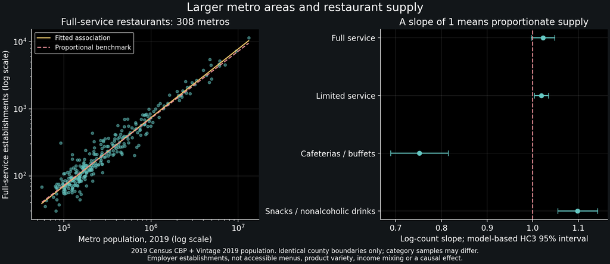

Restaurant supply and city size: fixed primary sample and all four industries

## Geographic and publication checks

CBP’s documented metropolitan reference covers 2017-2021; it is not automatically the September 2018 population geography. Of its 382 US metros, 308 have exactly matching county sets and metro status, 72 have different county membership, and two codes are absent from the 2018 reference. We do not silently match on the five-digit code. The CBP reference’s 551 micropolitan areas are excluded. The strict primary sample accounts for 74.61% of the newer reference’s metropolitan population, not all US metro residents. The broader, separately labelled sensitivity below is therefore important; boundary stability is not a random selection criterion.

For the primary sample, full- and limited-service counts cover all 308 metros. Buffets are published for 210 of the 308 eligible metros, containing 92.81% of the eligible sample’s population; snacks cover 307 metros and 99.96% of the same eligible population. Population coverage is not venue or visitor coverage. An omitted CBP cell is unknown here, not a zero. No suppressed count is reconstructed from totals.

## Predeclared boundary sensitivity

The sensitivity uses all 382 CBP-defined US metros, summing 2019 population over their own county membership only where every county has population. All 382 pass this completeness check. It does not relabel the primary sample or silently crosswalk an incompatible area.

| Industry | Metros with published counts | Slope | HC3 SE | 95% interval | R-squared | Per-resident change for doubled population |
| --- | --- | --- | --- | --- | --- | --- |
| Full-service restaurants | 382 | 1.0206 | 0.0113 | [0.9983, 1.0428] | 0.9426 | +1.44% |
| Limited-service restaurants | 382 | 1.0235 | 0.0068 | [1.0102, 1.0369] | 0.9790 | +1.64% |
| Cafeterias, grill buffets and buffets | 267 | 0.7647 | 0.0269 | [0.7120, 0.8174] | 0.7648 | -15.05% |
| Snack and nonalcoholic beverage bars | 381 | 1.0853 | 0.0193 | [1.0476, 1.1230] | 0.8731 | +6.09% |

Again the full-service interval includes proportionality. Buffet counts are unpublished in 115 metros (retained population coverage 93.51%); one snacks cell is absent (99.97% coverage). The boundary sensitivity does not resolve small-cell selection, within-metro accessibility or product differentiation.

## What this changes in the research plan

**Continue rank 2, but keep this as a supply benchmark.** The substantive question remains whether people from different-income home areas use different reachable centres, different products, or different venues within the same centre/service. Metropolitan counts cannot distinguish these.

The next income-accounting run still requires the named annual-flow and ACS inputs, mass reconciliation and producer geography checks. A later common-menu study additionally needs independent historical centre/tenant and product information. No coefficient here is a preference parameter, a measure of co-presence, or evidence that exposure changes attitudes. Counts are establishments, not firms, seats, opening hours, or accessible menus.

This is a different use of CBP from note 25’s historical county employment regressions. Those estimates were not rerun or endorsed by this exercise. The prior racial venue-count comparison, negative equal-county validation, correction 70a and failed public-facing gates are unchanged. Home-area income is still not individual income, and expected workers are not observed staff.

## Reproducibility and delivery

Source ZIP integrity, unique geographic/industry keys, complete county membership and positive published counts passed. Seven focused tests pass; the production rerun produces identical bytes for all three CSVs and the figure. The initial run stopped before estimation on the official label file’s legacy text encoding; a documented parser fix and regression test preceded the successful runs. No category or sample rule changed.

The independent audit reconstructs the geography from raw public sources and reproduces all eight coefficients and HC3 standard errors within 1e-10. Its two low-severity wording findings were corrected without changing any estimate, sample or protocol. The original review, response and release receipt are retained with the safe outputs. The full construction log records source URLs, hashes, dates, exact commands, software versions and output identities. Public geographic rows remain outside the repository; no restricted source was processed.

This note and its outputs are a local research milestone. They are not proof of upload to the shared Project, Space or website. Original protocols, historical outputs and source files are preserved.

# Public business-supply benchmark for the urban-scale proposal

20 October 2026. Prospective ancillary analysis, fixed before downloading or reading 2019 CBP establishment counts. This is not a replacement for the income-accounting pilot, independent opportunity inventory or replication. Historical literature/results and the pending restricted-file permissions are unchanged.

## Question and interpretation

Do larger metropolitan areas have proportionately more employer establishments within the same restaurant industry, or primarily more residents? An independent public count can establish a supply-side reference without relying on the mobility panel’s venue coverage. It does not identify accessible alternatives, product quality, cuisine, shared centres, income separation or preferences. This is supporting evidence for rank 2, not a standalone novelty claim.

## Sources and fixed scope

Use the official 2019 County Business Patterns metropolitan/micropolitan ZIP, the official 2017-2021 CBP county-membership reference and 2017 NAICS labels. Reuse the already validated Vintage 2019 county/CBSA population sources and September 2018 metropolitan reference from note 99, checking their hashes. No Dewey/Advan/ACS row-level data, workers or modern Green Book links enter. Public source bytes and derived metro rows stay outside the repository.

The primary industry is 2017 NAICS 722511, full-service restaurants. Report all three siblings 722513, 722514 and 722515 as secondary descriptive comparisons. Use official labels, not inferred price or interaction classes. Do not search other industries for a stronger coefficient.

Primary support: US50+DC metros whose complete county-key set and metro status agree between the CBP reference and the September 2018 reference. Exclude micros, Puerto Rico and divisions. Report every exclusion by reason. Matching codes alone are insufficient. Require at least 30 metros with published positive counts per reported regression; otherwise report support only.

One predeclared geography sensitivity resums 2019 county population over the CBP-defined US50+DC metropolitan county lists, only when every county key exists in the population source. This allows a different explicitly labelled geographic support; do not silently substitute it for the primary sample. No county crosswalk or partial sum is invented.

CBP omits cells below three establishments from publication. Missing or suppressed cells remain unknown, never zero; no log(1+x) substitution or suppression reconstruction. Validate unique metro-industry keys and nonnegative integer published establishment counts. Do not add industry parents to their children. Report category-specific coverage; comparisons with different retained samples are qualified.

## Estimand

For each fixed industry k and metro m, estimate equally weighted OLS:

log(establishments_mk) = alpha_k + beta_k log(population_m) + error_mk.

Report n, beta, HC3 model-based standard error/95% interval, R-squared and population coverage. Translate beta into the fitted count ratio 2^beta and the percentage change in establishments per resident, 100*(2^(beta-1)-1), associated with doubling metro population. The proportional benchmark is beta=1, not beta=0. No causal language, significance stars or claim that these intervals capture Census measurement error, spatial dependence or sampling uncertainty in a randomly sampled metro population. The secondary estimates are descriptive, not four independent confirmatory tests.

Do not add post-result controls, outlier deletions, alternate years or category searches. Verify the primary least-squares coefficient and HC3 covariance with independent arithmetic and preserve weak/contrary results. Produce a labelled scatter/fit and complete coefficient/support table.

## Acceptance and reporting

Stop before regression if source validation, membership validation, code uniqueness or count parsing fails. Resolve documented coding errors openly; do not revise the fixed sample/category choices after seeing estimates. Keep source URLs/hashes, timestamps, code/protocol hashes, merge counts and run commands. Re-execute from the saved public bytes and compare outputs.

This step can proceed while the independent Hamilton request and the named annual-flow/ACS permission remain pending. Even a strong supply gradient does not pass the original public-facing gates or establish Eren’s mechanism.

## Verified source documentation

- [Official 2019 files](https://www2.census.gov/programs-surveys/cbp/datasets/2019/).
- [CBP metro reference](https://www.census.gov/programs-surveys/cbp/technical-documentation/reference/metro-area-geography-reference.html).
- [Industry reference](https://www.census.gov/programs-surveys/cbp/technical-documentation/reference/naics-descriptions.html).
- [2019 table notes](https://data.census.gov/cedsci/table?hidePreview=true&q=CBP2019.CB1900CBP&tid=CBP2019.CB1900CBP): employer coverage and omitted small cells.
- The current general methodology page warns that its disclosure-method guidance is being revised. Do not apply a prospective 2026 change to the already released 2019 data.

# Construction record: 2019 public restaurant-supply benchmark

20 October 2026. Complete construction record for note 102. This is a new public-data empirical run, not new processing permission, an income-mixing estimate or a rerun of note 25.

## Frozen decisions and permitted inputs

`docs/protocols/cbp_urban_supply_benchmark_20261020.md` was written before acquiring the CBP count ZIP. The primary industry, three siblings, equal metro weights, two boundary samples, log-count model, HC3 covariance, minimum 30 observations and missing-cell handling were fixed there. The protocol is unchanged after estimates.

Only public Census sources were processed. Source files and metro rows are stored outside Git; reviewed coefficients, national support counts, the figure and receipts are eligible for the project. No restricted mobility, ACS microdata, employee workbook or Green Book feature rows enter.

## Sources and identity

Acquired 20 October 2026 using `prepare_cbp_urban_supply.py`. It uses an explicit three-URL allowlist, validates status/final URL, an HTML-content guard and size, verifies ZIP membership/CRC, and refuses an existing destination. Later runs verify source hashes against the acquisition manifest.

| File | Bytes | SHA-256 |
| --- | --- | --- |
| cbp19msa.zip | 6195283 | 45bcf8c5b8aa5faa266d3ac11b1f280a43b9e7f166478d30f2115b325a7c627c |
| msa_county_reference17.txt | 144851 | 46c3ac04cc4bde00763aa60fa0190a524f41112a85cd01fee9b0b2030e2b1e48 |
| naics2017.txt | 99360 | 959b8801c56df74a330bf02f853f7d389b1710d619fa5dd63577a36f783b7483 |

Official endpoints:

- https://www2.census.gov/programs-surveys/cbp/datasets/2019/cbp19msa.zip
- https://www2.census.gov/programs-surveys/cbp/technical-documentation/reference/metro-area-geography-reference/msa_county_reference17.txt
- https://www2.census.gov/programs-surveys/cbp/technical-documentation/reference/naics-descriptions/naics2017.txt

The exact acquisition times and final URLs are in `source_manifest.json`. The note 99 Vintage 2019 population/reference inputs are reused, not downloaded again. Their seven source hashes must match their stored verification receipt. The prior source-manifest SHA-256 is `46a4b3517626ef66a597aef3fe1aaf3c354220df1261a33db9fcf475f6f2a3df`. The reference CSV and county-membership output hashes are also checked.

## Data construction

1. Read county population summary level 050 for US50+DC, retaining FIPS as fixed-width text. Require a unique five-digit county key and positive integer 2019 population.
2. Parse CBP’s supplied county-membership file. Require the exact columns, valid keys, unique county membership and consistent metro names/types. The word MSA in a filename does not make every record metropolitan: 551 micros are excluded.
3. For each CBP metro compare its entire county set and metro status to the September 2018 reference. Only exact matches enter primary eligibility. Sum 2019 county population only if every member county is available. Exact-match sums must equal the previously built reference population.
4. Read only `msa`, `naics` and `est` from the ZIP’s single `cbp19msa.txt` member. Validate unique metro-industry keys and inclusion in the supplied geography reference. Every published count must parse as an integer of at least three. Select the four predeclared industry codes.
5. Join the official industry labels one-to-one. The legacy label file uses Windows-1252 punctuation; do not drop or guess undecodable labels.
6. Left-join each industry’s published counts to each eligible geographic sample, with `validate="one_to_one"`. Report unmatched cells; never fill them with zero or derive withheld counts from aggregate margins.
7. Separately estimate each industry’s log-count model with an intercept, equal metro weights and HC3 (`use_t=False`) normal 95% intervals. Report both geographic samples and all four industries. Transform the slope against proportionality (one), not against no association (zero).

There are 382 CBP US metros: 308 exact matches, 72 county-set differences and two absent codes in the 2018 reference. No CBP US metro lacks a member county’s 2019 population. The newer reference has 384 US metros; 76 are outside the primary matched set. Different denominators are deliberate. The independent raw-workbook check gives primary population 211,011,574 against 282,828,515 in the newer 384-metro reference (74.6076%). On the CBP boundary sensitivity the corresponding population is 282,237,518.

## Failure, repair and verification

The first six artificial tests passed. The first real run then stopped before fitting any model: pandas assumed UTF-8 for `naics2017.txt`, which contains byte 0x92. The repair introduced a strict Windows-1252 label reader, exact schema/key checks and an encoding regression test. All seven tests passed, followed by a successful production run and replay. Neither sample definitions nor outcome choices were changed.

Production and replay have byte-identical outputs:

| Output | SHA-256 |
| --- | --- |
| geography_support.csv | a0f3cf8ea0c4eeba74eac3d9f0aa1a0a2dc0c9c99b81195c0eec1f875cae16e9 |
| coefficients.csv | 33cf87e299e97a2ca56dc6cb9ad76b901be4387c843dc530510f3b120a593044 |
| public_metro_industry_sample.csv | 122de61e5f165f3e11344ffe8d2af454bc1561c4237d956e2472abccbdef679e |
| restaurant_supply_scaling.png | dbf1fb2c43220e967dbe1158755da56a08e2873217029d116e85326755027334 |

Production analysis elapsed 2.24 seconds; replay 2.48 seconds, excluding interpreter startup and the separate download. This is a small public-data calculation, not evidence about Hamilton runtime for the original panel. The figure was inspected at its rendered resolution: no clipped labels or overlaps. It labels the proportional reference and includes every category.

The independent reviewer separately reconstructed the geography from raw public sources and computed coefficients/HC3 from matrix arithmetic. All eight estimates agree within 1e-10. Its exact scope, two low-severity wording findings and residual limitations are in `independent_review.md` and its receipt. Both wording fixes were applied: the HTML-content guard is no longer called a MIME check, and category publication coverage explicitly uses all eligible metros as its denominator. No data or specification changed.

The reviewer-returned receipt is preserved as `independent_receipt_before_wording_fixes.json`. The checker was rerun after those edits to bind the corrected files; the unchanged review still records its original findings. `review_response.md` distinguishes those prose fixes from the independent numerical reconstruction. Source identity is not a substitute for methodology or a second substantive review.

## Exact execution

Work from the project root with Python 3.12 at the locally configured `PYTHON_EXECUTABLE`. The following commands use `python` as an abbreviation for that executable. Source/output directories below are public-data storage, not shared links.

```powershell
python -B code/analysis/prepare_cbp_urban_supply.py --destination PUBLIC_DATA_ROOT/cbp_urban_supply_2019_20261020
python -B -m unittest discover -s code/analysis -p test_cbp_urban_supply.py -v
python -B code/analysis/run_cbp_urban_supply.py --source PUBLIC_DATA_ROOT/cbp_urban_supply_2019_20261020 --population-source PUBLIC_DATA_ROOT/metro_population_reference_20261019 --reference-dir PUBLIC_DATA_ROOT/metro_population_reference_derived_20261019 --output PUBLIC_DATA_ROOT/cbp_urban_supply_derived_20261020
python -B code/analysis/run_cbp_urban_supply.py --source PUBLIC_DATA_ROOT/cbp_urban_supply_2019_20261020 --population-source PUBLIC_DATA_ROOT/metro_population_reference_20261019 --reference-dir PUBLIC_DATA_ROOT/metro_population_reference_derived_20261019 --output PUBLIC_DATA_ROOT/cbp_urban_supply_replay_20261020
python -B code/analysis/check_cbp_urban_supply_independent.py
python -B code/analysis/release_cbp_urban_supply.py --production PUBLIC_DATA_ROOT/cbp_urban_supply_derived_20261020 --replay PUBLIC_DATA_ROOT/cbp_urban_supply_replay_20261020 --pandoc PANDOC_EXECUTABLE
```

Do not rerun acquisition into an existing folder or overwrite either successful output. Use a fresh dated suffix for another replay, preserving the original verification JSON. The JSON records package versions, timestamps, protocol/code hashes, coverage counts and output hashes.

## Interpretation and limitations

The observed supply gradient is descriptive. Population and establishment counts are both measures of scale; a high R-squared is not mechanism identification. Full-service proportionality is compatible with the fixed model, not proven exactly. Unpublished small cells especially select the buffet sample. There is no model for that selection, no claim of spatially robust inference and no Census-uncertainty adjustment.

No count is an independently verified historical accessible choice set. Metropolitan totals omit within-metro distances, opening times, prices, products, capacity and individual constraints. The benchmark therefore neither validates nor rejects income sorting within a common menu.

Note 102 supplements the rank-2 proposal and note 99’s population reference. It does not supersede any original protocol or historical result, relax the named-source approval gate or restart a failed public-facing design.

# Independent review: public CBP restaurant-supply benchmark

20 October 2026. Bounded public-only review. Numeric and geographic audit: **PASS**. No material estimation, boundary, count-handling or inferential error found. Two low-severity documentation points follow; no production code or substantive document was changed by this reviewer.

## Findings, severity first

1. **P3, low: the construction record overstates acquisition validation.** `docs/data_construction/102_cbp_urban_supply_benchmark.md:23` says “validates status/final URL, MIME/HTML and size.” The acquisition code checks HTTP status, final URL, length, an HTML marker in the first 500 bytes, and ZIP structure/CRC. It does not inspect a MIME/Content-Type header (`code/analysis/prepare_cbp_urban_supply.py:59-70`). Replace “MIME/HTML” with “an HTML-content guard”; do not imply an unperformed MIME check. This does not invalidate the hash-verified, successfully parsed staged data.
2. **P3, low: clarify the population-coverage denominator.** `notes/102_cbp_urban_supply_benchmark.md:93` says buffets cover 210 metros and “92.81% of their combined population.” The denominator is the population of all **308 eligible primary metros**, not the 210 retained metros or all US metros. The calculation is correct, but the pronoun is ambiguous. Suggested wording: “Buffets are published for 210 of the 308 eligible metros, containing 92.81% of the eligible sample’s population.” The primary geography itself covers 74.6076% of the population in the 384 September 2018 US metros. Neither 100% category coverage nor 92.81% is a national coverage claim.

The latest note and construction-log revisions now explicitly report the 74.6076% boundary-sample coverage and the corresponding population totals. That addresses the broader boundary-selection qualification. The two narrow wording points above remain in the final audited bytes.

Neither point changes an estimate or requires a new specification. Retain the declared primary geography, the same four industry codes, and the category-specific publication samples. Do not replace them with an all-four-industries complete-case intersection.

## Independent construction and comparison

The checker reads the raw CBP county-membership text, raw September 2018 XLS delineation, raw county population CSV and raw CBSA population CSV. It uses standard-library CSV parsing and xlrd, not the production parsers or production estimator. Existing derived references are comparison targets, not inputs to the reconstructed county sets or populations.

- Raw CBP membership has 1,825 county records, 382 US50+DC metros and 551 micros. All micros are excluded. No Puerto Rico areas are present in this CBP membership source; the raw 2018 reference’s eight Puerto Rico metros and four micros are excluded. The 31 metropolitan division codes are not treated as independent metro observations.
- Primary eligibility is exactly **308** metros with matching complete county-key sets and metropolitan status. Of the other 74 CBP metros, 72 have different county sets and two codes are absent from the 2018 reference. A code-only match would incorrectly admit the 72.
- Viewed from the 384-metro 2018 reference, the 76 not in primary support comprise 72 boundary differences, three absent CBP codes and one area classified as a CBP micro. The two exclusion denominators are distinct.
- Sensitivity eligibility is exactly **382** CBP-defined metros. Every county population is present; no partial sum, crosswalk or imputation is used. Primary population sums equal raw published CBSA totals.
- All 3,142 county populations reconcile to 51 state/DC totals. All 926 US CBSA totals and 1,840 county components reconcile for 2019. All 1,915 derived 2018 membership records and 926 derived 2019 population records match their raw-source reconstruction.
- All **933** saved geography records, eligibility flags, populations and exclusion reasons match. All **2,545** retained sample observations match on geography, sample, industry, population, establishment count and label.
- All 569,017 published CBP metro-industry keys are unique and use known source areas. Counts are integer-valued and at least three; 3,013 rows belong to the four fixed industries before geographic restrictions. Missing cells stay unknown. No zero fill, log(1+x), parent-child summation or reconstruction of withheld counts occurs.

## Eight-row matrix check

Equally weighted OLS uses an intercept and natural logs. The independent checker computes `(X'X)^-1 X'y`, residuals, leverages, and `(X'X)^-1 X' diag(e_i^2/(1-h_ii)^2) X (X'X)^-1` directly. A centred basis improves conditioning; a second uncentred matrix calculation agrees. Intervals use the standard-normal 0.975 quantile, not a t critical value.

| Sample | NAICS | n | Slope | HC3 SE | Normal 95% interval |
| --- | --- | --- | --- | --- | --- |
| Primary | 722511 | 308 | 1.0224848874 | 0.0132073714 | [0.9965989152, 1.0483708596] |
| Primary | 722513 | 308 | 1.0187276054 | 0.0079016578 | [1.0032406406, 1.0342145702] |
| Primary | 722514 | 210 | 0.7517583469 | 0.0321428629 | [0.6887594934, 0.8147572005] |
| Primary | 722515 | 307 | 1.0985194176 | 0.0222186489 | [1.0549716658, 1.1420671693] |
| Sensitivity | 722511 | 382 | 1.0205832939 | 0.0113449866 | [0.9983475287, 1.0428190590] |
| Sensitivity | 722513 | 382 | 1.0235324202 | 0.0068267475 | [1.0101522410, 1.0369125993] |
| Sensitivity | 722514 | 267 | 0.7647037057 | 0.0268734056 | [0.7120327985, 0.8173746129] |
| Sensitivity | 722515 | 381 | 1.0853013285 | 0.0192588251 | [1.0475547248, 1.1230479321] |

Maximum absolute discrepancy from production: slope `8.89e-16`, HC3 SE `1.53e-16`, intercept `1.25e-14`, interval endpoints `8.89e-16`, R-squared `1.12e-16`, doubling count ratio `1.34e-15`, and per-resident percentage transformation `6.67e-14`. All pass the `1e-10` tolerance. The complete higher-precision results and difference checks are in the JSON receipt. All eight rows clear the minimum 30-observation gate.

## Suppression and interpretation

Primary publication omissions are 0, 0, 98 and 1 metros, in the declared industry order. Sensitivity omissions are 0, 0, 115 and 1. Buffet population coverage is 92.8072% in primary and 93.5081% in sensitivity; snacks cover 99.9616% and 99.9713%. These match production. In particular, primary buffet metro coverage is only 210/308, or 68.18%, despite the high population coverage. The missing cells cannot distinguish actual zero supply from withheld positive counts. Their values are not inferred.

The substantive note and construction record preserve the full-service result compatible with proportionality, the sublinear buffet result, and the larger snack gradient. The relevant reference is **beta = 1**, not zero. Primary full-service beta is 1.0225 with interval [0.9966, 1.0484]; the fitted per-resident change is +1.5707%, with interval [-0.2355%, +3.4097%]. Sensitivity also includes proportionality. This is not proof of exact equality, an equivalence test or a causal effect.

The caveats about published-cell selection, differing industry samples, employer establishments rather than firms/menus, model-based HC3 uncertainty, and lack of spatial or Census-error adjustment are appropriate. Neither document converts these regressions into evidence about mixing, preferences, accessibility, co-presence or attitudes. The statement that a positive count-population association alone cannot establish sorting is an identification caution, not an empirical rejection of a sorting mechanism. No alternative controls, years, categories or historical CBP regression was run or endorsed.

## Execution, hashes and limits

Run from the project root:

```powershell
python -B code/analysis/check_cbp_urban_supply_independent.py
```

Deliverables are `code/analysis/check_cbp_urban_supply_independent.py`, this review, and **`output/cbp_urban_supply_20261020/independent_receipt.json`**. The receipt records source/manifest, prior reference, production output, protocol, production code, reviewed-document, checker and review SHA-256 hashes, plus a canonical payload digest for the receipt itself. The checker prints the final JSON file’s full SHA-256. It rechecks input hashes before writing and exports no geographic rows or county identifiers.

The reviewer independently confirms that strict UTF-8 fails on the staged NAICS file and strict Windows-1252 yields the required unique labels. Current production places label parsing before its first estimation call. The historical failed-run chronology, seven production tests, byte-identical production replay and rendered-chart inspection are the main agent’s reported checks, not rerun evidence claimed by this audit.

Two audit-side parsing assumptions initially stopped this check: the saved membership CSV uses full type labels and UTF-8, and saved observation counts use integral floating-point text after the missing-cell merge. The checker was corrected to those observed formats; raw establishment counts remain strictly validated as integers. No production choice or value changed.

No download, browser, remote service, private data or external action was used. Source identities are verified against the stored manifests, not against a fresh provider request. The numeric PASS does not certify shared delivery or future edited documents; later changes require fresh hashes.

# Response to independent review

20 October 2026. Both P3 wording findings accepted and corrected.

1. Construction-log wording now describes the implemented HTML-content guard, not an unperformed MIME-header check.
2. The result note now explicitly gives all 308 eligible primary metros as the population-coverage denominator. Its separate 74.6076% share of the newer metropolitan population remains visible.

The review itself is unchanged. Its returned receipt is preserved as `independent_receipt_before_wording_fixes.json`. A subsequent execution of the independent checker binds the corrected note/log and reconfirms the same raw-source geography and eight numerical estimates. This is not a second independent prose review.

No source, outcome, industry, sample, coefficient, standard error or prospective protocol changed. No restricted data were processed, and no failed historical inference gate was reopened.

# Green Book: a Winston-Salem feasibility qualification

20 October 2026. Public-source finding for rank 3; not a historical sample reconstruction, modern POI match or economic estimate.

An official municipal announcement dated 3 October 2023 describes a Historic Resources Commission map of 18 Winston-Salem businesses listed in the Green Book during 1938-1967. It says that none of their original buildings remained standing at that time. [City of Winston-Salem announcement](https://wshome.cityofws.org/m/newsflash/Archive/Item/1313?arcId=2425).

**Implication:** do not select this city on the assumption that it supplies a comparison among surviving original buildings. A study of historical sites or surrounding districts could still be possible. The municipal statement does not establish demolition dates, the state of each location in 2017-2019, enterprise closure or relocation, or modern visitor composition. It is a dated official claim, not our independent inventory.

The linked [public StoryMap](https://storymaps.arcgis.com/stories/445478c7012f44ed9cb7cb281bdf725e) is a source lead, not a verified reusable dataset. Its item metadata was read; reuse/licence fields were blank. No underlying feature rows, photographs, oral histories or proprietor information were downloaded. The story’s full contents were not independently audited.

This finding reinforces note 100’s distinction between buildings, firms and sites; it does not resolve the NC master-frame/version/date questions. Rank 3 remains **narrow**, behind the contemporary descriptive and city-size questions. No new regression is warranted from this source alone.

## Retrieval record

Retrieved 20 October 2026, approximately 08:00 UTC. The municipal page was read again during documentation. Recorded HTTP-body fingerprints refer to the first retrieval; web pages may change independently of this snapshot.

| Retrieved object | Bytes | SHA-256 |
| --- | --- | --- |
| Municipal announcement HTML | 132096 | 28c50f97b4a8e77e528ba4dd0b18f9868b469d81b4fd8608706b997332e46387 |
| ArcGIS item metadata JSON | 2712 | 90181fd240bf09bd7fdba25d1e6dd5f70d75eea486dbeb478b2849ca43edc741 |

Metadata endpoint: https://www.arcgis.com/sharing/rest/content/items/445478c7012f44ed9cb7cb281bdf725e?f=json

Only source identities and this bounded summary are retained in the project; the complete HTML/JSON response bodies were not archived. These hashes are retrieval evidence, not an independently replayable record census. No restriction or historic finding is superseded.

## Source fingerprints and scope

- `notes/102_cbp_urban_supply_benchmark.md`: Complete authored result note. SHA-256 `de53ac4406bab864d03576a0dca1c0b50a7923b5f2ce097b41d669f0e39be3d1`.
- `docs/protocols/cbp_urban_supply_benchmark_20261020.md`: Complete unchanged prospective protocol. SHA-256 `b7f8f84054cec1c0ef94099c557dad467a0e0627dfcbf645f054fe54cfa5292d`.
- `docs/data_construction/102_cbp_urban_supply_benchmark.md`: Complete construction log; machine-specific path prefixes replaced with named placeholders. SHA-256 `30f50ba045254aead7953b60ce2fad998c4d43e3c583f81518de91c208e4c5e7`.
- `output/cbp_urban_supply_20261020/independent_review.md`: Complete independent review. SHA-256 `977b572b8a65e2814643f6cde77f51516e470fc38b87d4d4b3e590643926d30a`.
- `output/cbp_urban_supply_20261020/review_response.md`: Complete response to both wording findings. SHA-256 `ea8024510da7912463d5409080df6584aa989698eaee1df303c2efe8176966d4`.
- `notes/103_green_book_winston_salem_scope.md`: Complete source-only Green Book qualification. SHA-256 `c0dabd81fac919389c65221e0d0f6ecacb92baf8bfb72505f86257d7e3c5e77a`.